# Section 6: Modeling Autocorrelation and Heteroscedasticity with `nlme`

Keith Lohse, PhD, PStat

2026-08-04

Every model we have fit with `lme4::lmer()` so far in this repository makes one assumption that we have never actually stated out loud - although it was implicit in Section 1’s very first equation.

Recall the general form of a mixed-effects model from Section 1 (Equation 1 of the companion paper):
$$\mathbf{y} = \mathbf{X}\boldsymbol{\beta} +
\mathbf{Z}\boldsymbol{\gamma} + \boldsymbol{\epsilon}$$
where $\mathbf{y}$ is the vector of every observation across every subject, $\mathbf{X}\boldsymbol{\beta}$ is the fixed-effects part of the model, $\mathbf{Z}\boldsymbol{\gamma}$ is the random-effects part, and $\boldsymbol{\epsilon}$ is the vector of leftover residuals.

To talk about correlation *within* a subject over time, it helps to zoom in on one subject at a time – restricting Equation 1 to just subject $i$’s own rows:
$$\mathbf{y}_i = \mathbf{X}_i\boldsymbol{\beta} +
\mathbf{Z}_i\boldsymbol{\gamma}_i + \boldsymbol{\epsilon}_i$$
This is not a new model. It is the exact same equation, just written one subject’s block of rows at a time – the same partitioning that Figure 2 of the companion paper shows $\mathbf{Z}$ performing when it “spreads out” the random effects, $\boldsymbol{\gamma}$, into a share for each subject.

As we’ve previously discussed, every time we’ve written out a set of random effects (e.g., Section 2’s random-slopes model), that subject $i$’s own vector of random deviates follows a multivariate normal distribution – for instance, for a random intercept and random slope:
$$\begin{bmatrix}\gamma_{0i}\\
\gamma_{1i}\end{bmatrix} \sim
\mathcal{N}\left(\begin{bmatrix}0\\0\end{bmatrix},
\begin{bmatrix}\sigma_0^2 & \sigma_{01}\\ \sigma_{01} &
\sigma_1^2\end{bmatrix}\right)$$
We will now give that covariance matrix a name, $\mathbf{G}$, so that $\boldsymbol{\gamma}_i \sim \mathcal{N}(\mathbf{0}, \mathbf{G})$. Nothing about $\mathbf{G}$ is new here - it is the same matrix you have already been building throughout Sections 1-4, just represented by a single letter instead of spelled out in full every time.

What every model so far *has* quietly assumed, without ever writing it down this explicitly, is the analogous statement for the residuals: $\boldsymbol{\epsilon}_i \sim \mathcal{N}(\mathbf{0}, \sigma^2\mathbf{I})$ - every residual for subject $i$ has the same variance $\sigma^2$, and none of them correlate with one another. We can give this residual covariance matrix a name too, $\mathbf{R}_i$, so that $\boldsymbol{\epsilon}_i \sim \mathcal{N}(\mathbf{0}, \mathbf{R}_i)$. Up until now, $\mathbf{R}_i$ has simply *been* $\sigma^2\mathbf{I}$, we just never called it that.

Once both matrices have names, the total variance of subject $i$’s outcomes follows directly. $\mathbf{X}_i\boldsymbol{\beta}$ is a fixed quantity, not a random one, so it contributes nothing to the variance; and because $\boldsymbol{\gamma}_i$ and $\boldsymbol{\epsilon}_i$ are assumed independent of one another,
$$\text{Var}(\mathbf{y}_i) =
\text{Var}(\mathbf{Z}_i\boldsymbol{\gamma}_i + \boldsymbol{\epsilon}_i)
= \mathbf{Z}_i\,\text{Var}(\boldsymbol{\gamma}_i)\,\mathbf{Z}_i^T +
\text{Var}(\boldsymbol{\epsilon}_i)
= \mathbf{Z}_i \mathbf{G} \mathbf{Z}_i^T + \mathbf{R}_i$$

Thus far, we have principally discussed how to deal with statistical dependence through what is called the **“G-side”** matrix; that is, the specification of the **random effects**. However, especially when we have repeated observations at the lowest level of our data, we might also need to worry about the **“R-side”** matrix; that is, are there additional considerations we need to make about the (co)variance of our **residuals** above and beyond our random effects. Every model in Sections 1-4 fixed $\mathbf{R}_i = \sigma^2\mathbf{I}$ and let $\mathbf{G}$ do all of the work of describing dependency within a subject. `lme4` doesn’t give you a way to change this - $\mathbf{R}_i = \sigma^2\mathbf{I}$ is baked into how the package is built, which is part of why it is so fast even for complicated crossed random-effects structures (Section 8). Critically, if we have specified our random effects structure sufficiently, this is also a very reasonable assumption. However, treating $\mathbf{R}_i$ as a plain $\sigma^2\mathbf{I}$ may not always be sufficient. Specifically, there are two properties of our residuals that we need to concern ourselves with:

1. **Autocorrelation.** Observations closer together in time, from the same subject, tend to be *more* similar to each other than observations further apart. A person having an unusually good day at Week 3 is a better predictor of Week 4 than of Week 40.
2. **Heteroscedasticity.** The variance of the residuals can change systematically over time, across conditions, or across groups – e.g., people’s scores might be tightly clustered right after admission and much more spread out a year later, as some people have recovered fully and others have not.

The `nlme` package (which we already used for the negative-exponential growth model in Section 2) lets us model both of these directly, by specifying an explicit structure for $\mathbf{R}_i$ – on top of whatever $\mathbf{G}$ we’ve already chosen for the random effects – instead of accepting the default $\sigma^2\mathbf{I}$.

## 6.1. Common Residual Covariance Structures

- **Compound Symmetry (`corCompSymm`)**: a single correlation $\rho$ between *any* two time points from the same subject, regardless of how far apart they are. This is the same assumption implicit in a repeated-measures ANOVA when sphericity holds (see Section 3; a random-intercept-only mixed model is mathematically equivalent to compound symmetry.
- **Autoregressive Order 1 (`corAR1`)**: correlation decays geometrically with each discrete time step, $\text{Corr}(\epsilon_t, \epsilon_{t+k}) = \rho^{|k|}$. This is a natural choice when your time points are evenly spaced (Trial 1, 2, 3, 4…) and you expect the “good day/bad day” carryover to fade steadily rather than staying constant.
- **Continuous AR1 (`corCAR1`)**: the same idea as `corAR1`, but for *continuously* and (potentially) *irregularly* spaced time – exactly the situation we described in Section 2, where our spinal-cord-injury data were “collected on different days for different people,” so that Month 3 for one participant might really be Day 85 and for another Day 95.
- **Unstructured (`corSymm`)**: no assumed pattern at all – every pair of time points gets its own, freely-estimated correlation. This is the most flexible option but also the most informationally “expensive”: with $T$ time points it estimates $T(T-1)/2$ separate correlation parameters, which can quickly become more than your data can support.

## 6.2. A Simulated Example: Recovering a Known AR(1) Process

To see these ideas clearly, we will first simulate data where we know the true answer: 30 subjects, measured at 6 evenly-spaced time points, with residuals that (a) truly follow an AR(1) process with $\rho = 0.65$ and (b) truly grow more variable over time.

```r
library(tidyverse)
library(nlme)
```

```r
set.seed(2026)
n_subjects <- 30
n_timepoints <- 6

df_nlme <- expand.grid(
  subID = factor(1:n_subjects),
  time  = 1:n_timepoints
) %>%
  arrange(subID, time)

sigma_base <- 1.0 # baseline variance
rho_true <- 0.65 # true correlation

# Build each subject's residual trajectory in two steps. First, a properly stationary
# AR(1) base process with constant unit variance throughout -- the sqrt(1 - rho_true^2)
# term on each innovation is essential here; without it, the AR(1) recursion's own
# variance compounds on top of whatever heteroscedasticity we add next, and rho and the
# variance pattern stop being cleanly separable. Second, scale that base process by the
# intended heteroscedasticity pattern, so the growing variance is exactly what we say it
# is, and nothing more.
df_nlme$residual <- unlist(lapply(1:n_subjects, function(i) {
  base <- numeric(n_timepoints)
  base[1] <- rnorm(1, 0, 1)
  for (t in 2:n_timepoints) {
    base[t] <- rho_true * base[t-1] + rnorm(1, 0, sqrt(1 - rho_true^2))
  }
  var_scale <- 1 + 0.2 * (0:(n_timepoints - 1))
  sigma_base * sqrt(var_scale) * base
}))

df_nlme <- df_nlme %>%
  mutate(score = 5.0 + 0.8 * time + residual)
```

## 6.3. Fitting Three Increasingly Realistic Models

We’ll fit the same fixed effect of `time` three times, adding one piece of residual structure at each step, so we can watch model fit improve as our assumptions get closer to how the data were actually generated.

```r
# Model 1: standard random-intercept model. i.i.d. residuals -- our lme4 default assumption.
m1_iid <- lme(
  fixed  = score ~ time,
  random = ~ 1 | subID,
  data   = df_nlme,
  method = "REML"
)

# Model 2: adds an AR(1) residual correlation structure within each subject.
m2_ar1 <- lme(
  fixed       = score ~ time,
  random      = ~ 1 | subID,
  correlation = corAR1(form = ~ time | subID),
  data        = df_nlme,
  method      = "REML"
)

# Model 3: adds a variance function on top of the AR(1) structure, letting the residual
# variance differ freely at each time point (varIdent estimates one scale factor per level
# of its grouping variable -- nlme treats `time` as a grouping factor here even though the
# column itself is numeric, so this correctly gives us one variance parameter per time point).
m3_ar1_var <- lme(
  fixed       = score ~ time,
  random      = ~ 1 | subID,
  correlation = corAR1(form = ~ time | subID),
  weights     = varIdent(form = ~ 1 | time),
  data        = df_nlme,
  method      = "REML"
)
```

```r
anova(m1_iid, m2_ar1, m3_ar1_var)
```

|  | call | Model | df | AIC | BIC | logLik | Test | L.Ratio | p-value |
| --- | --- | --- | --- | --- | --- | --- | --- | --- | --- |
| m1_iid | lme.formula(fixed = score ~ time, data = df_nlme, random = ~1 \| subID, method = "REML") | 1 | 4 | 539.3428 | 552.0699 | -265.6714 |  | NA | NA |
| m2_ar1 | lme.formula(fixed = score ~ time, data = df_nlme, random = ~1 \| subID, correlation = corAR1(form = ~time \| subID), method = "REML") | 2 | 5 | 517.7026 | 533.6116 | -253.8513 | 1 vs 2 | 23.64012 | 1.161406e-06 |
| m3_ar1_var | lme.formula(fixed = score ~ time, data = df_nlme, random = ~1 \| subID, correlation = corAR1(form = ~time \| subID), weights = varIdent(form = ~1 \| time), method = "REML") | 3 | 10 | 505.8578 | 537.6757 | -242.9289 | 2 vs 3 | 21.84479 | 5.603891e-04 |

Each model is nested inside the next (Model 2 adds one correlation parameter to Model 1; Model 3 adds five variance-ratio parameters to Model 2), so the likelihood-ratio tests in this table are valid, and both are highly significant: allowing for autocorrelation improves the fit substantially, and allowing the residual variance to grow over time improves it further still. This matches how we built the data, which of course we rigged in advance. The value of doing this with simulated data first is exactly that you get to confirm the method recovers a structure you already know is there before trusting it on real data where you don’t.

## 6.4. Visualizing the Autocorrelation Directly

Beyond checking the numeric value of $\hat\rho$, it is good practice to look at the residual autocorrelation function (ACF) directly, both before and after adding the `corAR1` term. Keep in mind that for this example, we have “baked in” a specific auto-correlation for our simulated data. In reality, we don’t know what the “true” autocorrelation is, so instead we would be looking for any evidence of residual autocorrelation:

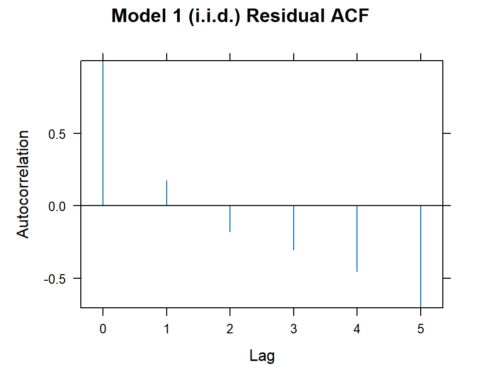

```r
# ACF()'s default residuals (resType = "pearson") are NOT adjusted for a model's fitted
# correlation structure, so they will not show whether corAR1 actually worked. Use
# resType = "normalized" instead. See the "Technical notes" here for the same fix in
# another worked example: https://bbolker.github.io/mixedmodels-misc/notes/corr_braindump.html
plot(ACF(m1_iid, maxLag = 5, resType = "normalized"), main = "Model 1 (i.i.d.) Residual ACF")
```

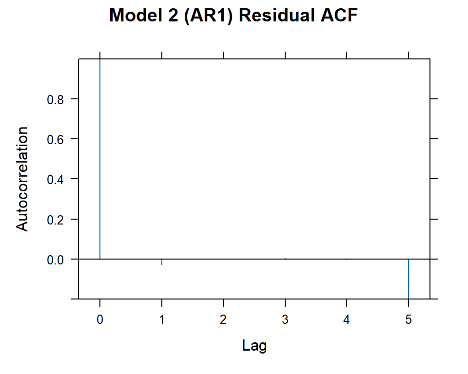

```r
plot(ACF(m2_ar1, maxLag = 5, resType = "normalized"), main = "Model 2 (AR1) Residual ACF")
```

## 6.5. A Real-Data Example: Continuous Time with `corCAR1`

The simulated example above uses evenly-spaced integer time points (1 through 6), which is exactly the situation `corAR1` was built for. But recall the longitudinal spinal-cord-injury data from Section 2 (`data_SCI_longitudinal_example.csv`): “these data were all collected on different days for different people… Month 1 as a time point might be Day 20 for some people, but Day 30 for others.” That is precisely the situation `corCAR1` (continuous-time AR1) is designed for, and we don’t need to simulate anything new to see it in action – we can go straight back to real data we’ve already loaded once before.

It’s worth pausing on what Section 2 actually *did* with this exact dependency problem, because it is a clean illustration of the distinction between G-side and R-side modeling that we discussed at the beginning. Section 2 never touched $\mathbf{R}_i$ at all – every one of its models used a plain $\sigma^2\mathbf{I}$ for the residuals. Instead, it handled the fact that a person’s functional-independence scores over time are not independent entirely through $\mathbf{G}$, by building an increasingly rich random-effects structure: a random intercept, then a random linear slope for `year.0`, then a random quadratic term, then a random cubic term – each addition justified by a significant likelihood-ratio test ($\chi^2(3)=1046.98$, then $\chi^2(4)=746.46$, then $\chi^2(5)=252.32$). That is twelve additional variance and covariance parameters, across three model comparisons, spent on capturing more and more of the within-subject dependency by letting each person’s *own trajectory shape* bend to fit their data. This was a perfectly reasonable strategy – per Part 6.6 (below), a rich enough $\mathbf{G}$ can produce well-calibrated fixed-effect tests without ever modeling $\mathbf{R}_i$ explicitly, and Section 2 was, after all, primarily interested in testing whether AIS Grade predicts the *shape* of that trajectory, which needed those polynomial fixed effects regardless.

`corCAR1` offers a genuinely different way to attack the same underlying dependency. Instead of asking $\mathbf{G}$ to become progressively richer, one polynomial term at a time, it models the persistence directly, in $\mathbf{R}_i$, with a single interpretable parameter: how strongly today’s score predicts a score close in time, decaying continuously the further apart two assessments are. Let’s fit the simplest possible version – deliberately using only a linear fixed effect of `year.0` and only a random *intercept*, so that whatever improvement we see is attributable to $\mathbf{R}_i$ alone, not to a richer $\mathbf{G}$:

```r
DAT2 <- read.csv("https://raw.githubusercontent.com/keithlohse/mixed_effects_models/master/data_SCI_longitudinal_example.csv",
                 stringsAsFactors = TRUE)
DAT2$year.0 <- (DAT2$time - 1) / 12

m_iid_real  <- lme(rasch_FIM ~ year.0, random = ~ 1 | subID, data = DAT2, method = "REML")
m_car1_real <- lme(rasch_FIM ~ year.0, random = ~ 1 | subID,
                    correlation = corCAR1(form = ~ year.0 | subID),
                    data = DAT2, method = "REML")

anova(m_iid_real, m_car1_real)
```

|  | call | Model | df | AIC | BIC | logLik | Test | L.Ratio | p-value |
| --- | --- | --- | --- | --- | --- | --- | --- | --- | --- |
| m_iid_real | lme.formula(fixed = rasch_FIM ~ year.0, data = DAT2, random = ~1 \| subID, method = "REML") | 1 | 4 | 4936.58 | 4954.886 | -2464.29 |  | NA | NA |
| m_car1_real | lme.formula(fixed = rasch_FIM ~ year.0, data = DAT2, random = ~1 \| subID, correlation = corCAR1(form = ~year.0 \| subID), method = "REML") | 2 | 5 | 4150.74 | 4173.623 | -2070.37 | 1 vs 2 | 787.84 | 2.376255e-173 |

```r
summary(m_car1_real)$modelStruct$corStruct
```

```
## Correlation structure of class corCAR1 representing
##       Phi
## 0.5088818
```

The improvement in fit here is enormous, and reflective of patterns you’d likely see in real data – functional independence really does show strong day-to-day/month-to-month carryover within a person (someone recovering quickly at Month 3 is very likely to still be recovering quickly at Month 4). Notice what it took to get here, however: Section 2 spent twelve parameters, across an intercept, a slope, a quadratic, and a cubic random effect, progressively chipping away at within-subject dependency while *also* building a detailed picture of average recovery curvature. Here, a *single* additional parameter – $\hat\rho$ – captures a comparable order of magnitude of improvement (a likelihood-ratio statistic of 787.84, on just 1 degree of freedom), because it is aimed squarely at the dependency itself rather than approximating it by modeling trajectory shape. This is not quite an apples-to-apples comparison – Section 2’s rich $\mathbf{G}$ was doing double duty, capturing genuine nonlinear curvature *and* individual differences in that curvature. In contrast, `corCAR1` alone tells us nothing about individual or group level trajectories, but it does give us a parsimonious way of dealing with statistical dependency in our residuals.

The two different approaches are not mutually exclusive, either. Nothing stops you from combining them – fitting Section 2’s cubic random-effects growth curve *and* an explicit `corCAR1` term in the same model, if you have reason to think meaningful residual autocorrelation remains even after allowing each person their own curve. In practice, with only 40 subjects, that combined model is asking a great deal of the data at once, and Section 3’s discussion of singular fits is a good reminder to check convergence carefully – and to consider, per Part 6.6.4, whether your actual research question (testing a fixed effect vs. interpreting the variance components) calls for that additional complexity at all – before trusting it.

This is also a good habit to build for its own sake: whenever this repository already has a real dataset whose design fits the technique you’re learning, it’s worth running the new technique on it, rather than only ever practicing on data you simulated yourself. You already know quite a lot about this dataset from Section 2 (e.g., the growth curves in Figure/plot form, the negative-exponential model, the AIS Grade comparisons), and layering `corCAR1` on top of that existing understanding – and directly comparing it to the strategy Section 2 already used – is a much faster way to build intuition than starting over with an unfamiliar variable name.

## 6.6. When Does the G-Side/R-Side Distinction Actually Matter?

We now have the tools to model $\mathbf{R}_i$ directly, which raises a sharper question than “why don’t we always use `nlme`”: given that $\text{Var}(\mathbf{y}_i) = \mathbf{Z}_i \mathbf{G} \mathbf{Z}_i^T + \mathbf{R}_i$ simply *adds* the two pieces together, how much does it actually matter whether a given source of dependency is captured by $\mathbf{G}$ or by $\mathbf{R}_i$? The honest answer depends heavily on what you are using the model for – and it is different for the two things we typically want out of a mixed-effects model: testing fixed effects, and interpreting the random effects themselves.

### 6.6.1 Fixed-Effect Point Estimates: Robust to the G/R Partition

Every mixed model estimates its fixed effects using a form of generalized least squares: observations get combined into an estimate of $\boldsymbol{\beta}$, weighted by how much information each one is assumed to carry, where those weights come directly from the model’s assumed covariance structure, $\mathbf{Z}_i \mathbf{G} \mathbf{Z}_i^T + \mathbf{R}_i$. If that assumed structure is *somewhat* wrong – say, because real residual autocorrelation gets folded into $\mathbf{G}$ instead of being modeled explicitly as $\mathbf{R}_i$ – the weights used to combine observations are no longer the *most efficient* possible weights, but they remain a reasonable, unbiased way to combine the data. This is the same basic robustness property that keeps ordinary regression coefficients unbiased even under heteroscedasticity: getting the variance structure wrong costs you precision, and (as the next section shows) can cost you calibration, but it does not, in general, introduce bias into the point estimate itself.

### 6.6.2 Fixed-Effect Standard Errors: Depends on Whether G Is Rich Enough

Standard errors are a different story, because they depend directly on how much *independent* information the model believes it has. Picture a subject’s scores over time genuinely following an autocorrelated, “streaky” pattern – a run of a few good days, then a run of a few bad days – rather than bouncing around independently from one time point to the next. A model built only on a random intercept assumes **compound symmetry**: any two of that subject’s time points are equally correlated, no matter how close together or far apart they are. Such a model has no way to distinguish “four genuinely independent measurements” from “four measurements drawn from the same short streak.” It ends up treating a temporally clustered, highly-correlated run as if it carried nearly as much information as four independent looks at the subject’s true trend – which overstates the precision of that trend estimate and understates its standard error. The risk is highest specifically for fixed effects that describe *change over time* (like a slope), since that is exactly the kind of estimate a “streaky” pattern can most easily fool.

A random **slope** changes this picture substantially. Once each subject is allowed their own individual line – their own intercept and their own rate of change – a temporary streak (a subject who happens to be running high across several adjacent time points) can be partly absorbed into that subject’s own line, instead of being mistaken for extra evidence about the population-level trend. This does not literally “discover” that an autocorrelated process generated the data – the model still has no explicit concept of residual autocorrelation – but a random slope is flexible enough to approximate a good share of the same pattern (runs of similar values, within a subject, over nearby time points), which tends to pull the resulting fixed-effect standard errors back toward being well-calibrated, even without ever touching $\mathbf{R}_i$ directly.

The practical lesson: **the risk of an anti-conservative fixed-effect standard error is highest when $\mathbf{G}$ is sparse** – often just a random intercept – **and the true dependency has real structure over time** (autocorrelation, or variance that changes with time). A random-effects structure with slopes that track the shape of your growth curves, exactly as Sections 2 and 4 already recommend, substantially closes that gap, because it gives the model a flexible, subject-specific way to absorb exactly the kind of statistical dependence that we would otherwise need to model with a more complex $\mathbf{R}_i$.

### 6.6.3 Random-Effect Variance Components: Where the Partition Matters Much More

Unliketing estimating/testing fixed effects, estimating the variance of random effects is a different matter entirely, because they *are* the answer to “how is the total variance divided up” – and that is precisely the question a G/R misattribution gets wrong. Picture the total variance in your outcome as a pie, correctly sized: a model that folds real residual autocorrelation into $\mathbf{G}$ instead of modeling it explicitly as $\mathbf{R}_i$ is not making the pie the wrong size – it is cutting the *same* pie along the wrong lines. Some of what should properly be described as “unexplained, time-varying noise within a subject” ($\mathbf{R}_i$) gets relabeled as “this subject’s true, stable individual difference” ($\mathbf{G}$), which typically inflates the estimated between-subject (intercept) variance.

If your model also includes a random slope, the story gets one layer more complicated: some of that same misattributed variance can get pulled specifically into the *slope* variance instead of the intercept variance, since a random slope is one of the more flexible tools the model has available for approximating a “streaky,” time-varying pattern. That can make it look as though people genuinely differ in their rate of change, when a meaningful share of that apparent variability is actually unmodeled residual dependency, misattributed to the wrong place in $\mathbf{G}$.

This is the asymmetry worth remembering: **a fixed-effect hypothesis test can come out well-calibrated using nothing but a rich $\mathbf{G}$, because it only cares about the *total* variance behind the estimate; but if your actual research question is about the variance components themselves** – how much people differ in level, or in trajectory, a reasonable and clinically meaningful question in rehabilitation research (Sections 2 and 8) – **the G/R partition matters much more**, because a model can pass a well-calibrated fixed-effect test while still giving a distorted answer to random effects.

## Summary

- $\mathbf{G}$ (random effects) and $\mathbf{R}_i$ (residuals) both contribute to $\text{Var}(\mathbf{y}_i)$, and a sufficiently rich $\mathbf{G}$ – like the random-slope growth-curve models built in Sections 2 and 4 – can already capture a meaningful share of real autocorrelation, without ever touching $\mathbf{R}_i$. `lme4`’s inability to model $\mathbf{R}_i$ directly is a real but narrow limitation, not a general inadequacy for longitudinal data.
- Fixed-effect point estimates are robust to how dependency is partitioned between $\mathbf{G}$ and $\mathbf{R}_i$. Fixed-effect standard errors are *not* automatically robust to this – they tend to be well-calibrated when $\mathbf{G}$ is rich enough to approximate the true dependency (e.g., a random slope that can absorb “streaky,” time-correlated patterns), and can be meaningfully anti-conservative when $\mathbf{G}$ is sparse (e.g., if you only have a random intercept, which cannot represent anything beyond a constant, compound-symmetric correlation).
- The variance components themselves are considerably more sensitive to this partition than the fixed effects are – a model can pass a fixed-effect calibration check while still giving a biased answer to “how much do subjects differ,” because it achieved that calibration by misattributing dependency to the wrong variance component.
- `nlme::lme()` lets you specify an explicit residual correlation structure (`correlation = corAR1(...)`, `corCAR1(...)`, `corCompSymm(...)`, `corSymm(...)`) and/or an explicit variance function (`weights = varIdent(...)`, among others) – reach for it when the variance components are your actual question, your time structure doesn’t fit a low-order polynomial random-effects structure, your $\mathbf{G}$ is sparse relative to the true dependency, or the dependency structure is itself the finding.
- Compare models sequentially with `anova()` (a nested-model likelihood-ratio test, just as we did for the unconditional growth models in Section 2) rather than jumping straight to the most complex structure.
- Misspecifying one piece of the covariance structure (e.g., leaving out heteroscedasticity) can bias your estimates of a different piece (e.g., the autocorrelation parameter) – inspect more than one diagnostic before concluding a model is “good enough.”

## References

Pinheiro, J., & Bates, D. (2006). *Mixed-effects models in S and S-PLUS*. Springer.

Pinheiro, J., Bates, D., & R Core Team. (2022). nlme: Linear and Nonlinear Mixed Effects Models. https://CRAN.R-project.org/package=nlme